```python
import numpy as np
from matplotlib import pyplot as plt
import math
import os
from collections import Counter, defaultdict, deque
import time
```

# 100 задач в python

Курс "Модели и методы интеллектуального анализа данных"

Чернышов Юрий

к.ф.-м.н., доцент кафедры ИТЗИ УрГУПС (Екатеринбург)

yuchernyshov@usurt.ru

# Оглавление

# Введение

Документ содержит практические примеры работы с языком программирования Python.

Материал состоит из 100 типовых задач, которые можно выполнить с помощью Python.

Для удобства задачи разбиты на группы, к которым можно быстро перейти через Оглавление.

Язык Python был создан в 1991 году. В настоящее время интерес к использованию Python возрос в связи с большим количеством разработанных специализированных библиотек для отдельных задач, многочисленным сообществом разработчиков, а также применением Python для важных практических задач: математического моделирования, научных исследований, обработки данных и пр. Python является одним из основных инструментов при решении задач машинного обучения.

Python - интерпретируемый язык программирования. Программа Python (также используется термин скрипт) состоит из команд, которые последовательно выполняются интерптетатором Python.

Python проигрывает в скорости выполнения программ компилируемым языкам программирования (например, C), но имеет ряд преимуществ - наглядность, простота, лаконичность, популярность. Для быстрого предварительного исследования, моделирования, проверки гипотез, визуализации использование Python предпочтительнее.

Для выполнения заданий не обязательно устанавливать Python локально, можно воспользоваться одним из популярных открытых инструментов (см. Полезные ссылки), например https://colab.research.google.com.

Назад к Оглавлению

# Переменные, типы данных, простейшие операции

#### Объявление переменной. Вывод на экран.

```python
a = 1
print(a)
print(type(a))
```

```
1
<class 'int'>
```

```python
s = "Hello, world!"
print(s)
print(type(s))
```

```
Hello, world!
<class 'str'>
```

#### Комментарии

```python
# однострочный комментарий
```

```python
'''
это строковая переменная,
но здесь она используется как
комментарий из нескольких строк
'''
```

```
'\nэто строковая переменная,\nно здесь она используется как\nкомментарий из нескольких строк\n'
```

```python
#но лучше многострочный комментарий
#делать так
#asdf
#asdf
#asdf
#asdf
#asdf
```

#### Получение справки

При описании функции текст заключается в тройные кавычки (""" в начале и в конце) и потом используется для docstring.

```python
def f():
    """
    Функция f()
    """
    print("Hello")
```

```python
f?
```

```python
min?
```

#### Структура программы. Отступы.

```python
for i in range(3):
# тело цикла выделяется отступом, обычно 4 пробела.
    print(i)
```

```
0
1
2
```

```python
def f():
# тело функции выделяется отступом, обычно 4 пробела.
    return "Привет"

f()
```

```
'Привет'
```

#### Импорт модулей

```python
from math import *
sqrt(4)
sin(-2)
```

```
-0.9092974268256817
```

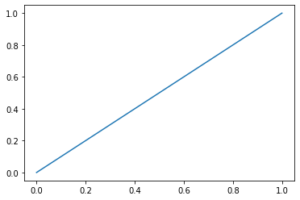

```python
from matplotlib import pyplot as plt
plt.plot([0,1],[0,1])
plt.show()
```

#### Видимость переменной. Глобальные и локальные переменные.

```python
a = 10
def f1():
    global a
    a += 1
    print("f1, a={}".format(a))

def f2():
    a = 15
    a += 1
    print("f2, a={}".format(a))

print("global a={}".format(a))
f1()
print("global a={}".format(a))
f2()
print("global a={}".format(a))
f1()
```

```
global a=10
f1, a=11
global a=11
f2, a=16
global a=11
f1, a=12
```

#### Операция присваивания значения переменной

```python
a,b = 1,2
print("a={}, b={}".format(a,b))
a,b = b,a
print("a={}, b={}".format(a,b))
```

```
a=1, b=2
a=2, b=1
```

#### Операции сложения, вычитания, умножения

```python
a = 1
print(a+1, a-1, a*2)
```

```
2 0 2
```

#### Операция деления. Целая часть, остаток от деления.

```python
print(10/3, 10//3, 10%3)
```

```
3.3333333333333335 3 1
```

```python
a,b = divmod(10,3)
print(a,b)
```

```
3 1
```

#### Короткая запись операций

```python
a = 1
print(a)
a += 1
print(a)
a *= 2
print(a)
a /= 3
print(a)
```

```
1
2
4
1.3333333333333333
```

#### Возведение в степень, извлечение корня

```python
print(2**2, 4**(1/2))
```

```
4 2.0
```

#### Типы переменных

```python
for elem in [1, 1., 1j, 1e-1, "one", True]:
    print(type(elem))
```

```
<class 'int'>
<class 'float'>
<class 'complex'>
<class 'float'>
<class 'str'>
<class 'bool'>
```

#### Логический тип данных

```python
2*2==5
```

```
False
```

```python
list(range(10))
```

```
[0, 1, 2, 3, 4, 5, 6, 7, 8, 9]
```

```python
for x in range(10):
    if x%3:
        print("Да", end=", ")
    else:
        print("Нет", end=", ")
```

```
Нет, Да, Да, Нет, Да, Да, Нет, Да, Да, Нет,
```

```python
False == False in [False]
```

```
True
```

```python
bool(0), bool(""), bool([]), bool({}), bool(()), bool(set())
```

```
(False, False, False, False, False, False)
```

#### Распаковка объектов (оператор "*")

```python
a = [1, 2, 3]
b = [*a, 4, 5]
print(b)
```

```
[1, 2, 3, 4, 5]
```

```python
d1 = {"первый": 1, "второй": 2}
d2 = {*d1, "третий"}
print(d2, type(d2))
```

```
{'третий', 'первый', 'второй'} <class 'set'>
```

#### Функции, структурированные типы данных.

```python
a=[]
def f():
    return 123
a.append(f)
l = lambda :'123'
a.append(l)
a.append([1,2,3])
a.append((1,2,3,))
a.append("123")
a.append({'a':1, 'b':2, 'c':3})
a.append({1,2,3})
a.append((i for i in range(1,4)))
for i in a:
    print(type(i), repr(i), i)
```

```
<class 'function'> <function f at 0x02C55FA8> <function f at 0x02C55FA8>
<class 'function'> <function <lambda> at 0x02C698A0> <function <lambda> at 0x02C698A0>
<class 'list'> [1, 2, 3] [1, 2, 3]
<class 'tuple'> (1, 2, 3) (1, 2, 3)
<class 'str'> '123' 123
<class 'dict'> {'a': 1, 'b': 2, 'c': 3} {'a': 1, 'b': 2, 'c': 3}
<class 'set'> {1, 2, 3} {1, 2, 3}
<class 'generator'> <generator object <genexpr> at 0x0A60A0B0> <generator object <genexpr> at 0x0A60A0B0>
```

#### Нумерование элементов

```python
for i in enumerate(['a', 'b', 'c']):
    print(i)
```

```
(0, 'a')
(1, 'b')
(2, 'c')
```

#### Сортировка

```python
a = [1, -3, 2, -4, 3, -5, 4, -6, 5, -7, 6, -8]
```

```python
sorted(a)
```

```
[-8, -7, -6, -5, -4, -3, 1, 2, 3, 4, 5, 6]
```

```python
sorted(a, reverse=True)
```

```
[6, 5, 4, 3, 2, 1, -3, -4, -5, -6, -7, -8]
```

```python
sorted(a, key=abs)
```

```
[1, 2, -3, 3, -4, 4, -5, 5, -6, 6, -7, -8]
```

#### Минимальный и максимальный элементы

```python
a = [1, 2, 3, 4, 5]
min(a), max(a)
```

```
(1, 5)
```

#### Свойства объекта

```python
a = 1
for s in dir(a):
    print(s, end="   ")
a.__sizeof__()
```

```
__abs__   __add__   __and__   __bool__   __ceil__   __class__   __delattr__   __dir__   __divmod__   __doc__   __eq__   __float__   __floor__   __floordiv__   __format__   __ge__   __getattribute__   __getnewargs__   __gt__   __hash__   __index__   __init__   __init_subclass__   __int__   __invert__…
```

```
14
```

Назад в Оглавление

# Структурированные типы данных

## Строки

```python
"asd".isalpha()
```

```
True
```

```python
"5".isdigit()
```

```
True
```

```python
"hello, world!".upper()
```

```
'HELLO, WORLD!'
```

```python
"HI!".lower()
```

```
'hi!'
```

```python
"some text is here".capitalize()
```

```
'Some text is here'
```

```python
"Very interesting sentence".split()
```

```
['Very', 'interesting', 'sentence']
```

```python
"А роза упала на лапу Азора"[::-1]
```

```
'арозА упал ан алапу азор А'
```

```python
"words This text contains words".find('word')
```

```
0
```

```python
"words This text contains words".rfind('s')
```

```
29
```

```python
"a, b, c".replace(',', '')
```

```
'a b c'
```

```python
ord('a'), ord('z'), ord('A'), ord('Z')
```

```
(97, 122, 65, 90)
```

```python
chr(5), chr(70)
```

```
('\x05', 'F')
```

#### Форматирование строк

```python
a, b = 1, 2
print("a={}, b={}".format(a, b))
```

```
a=1, b=2
```

```python
a, b = 1, 2
print("a={:.2f}, b={:.5f}".format(a, b))
```

```
a=1.00, b=2.00000
```

```python
x = 1234567
print('{0:,}'.format(x))
```

```
1,234,567
```

```python
x = 1234567
print('{0:,}'.format(x).replace(',', ' '))
```

```
1 234 567
```

Назад к Оглавлению

## Списки

```python
a = [1, 2, 3]
print(a)
print(a[0])
print(a[-1])
```

```
[1, 2, 3]
1
3
```

```python
a = list(range(10))
print(a)
```

```
[0, 1, 2, 3, 4, 5, 6, 7, 8, 9]
```

```python
a = [i**2 for i in range(1,11)]
print(a)
```

```
[1, 4, 9, 16, 25, 36, 49, 64, 81, 100]
```

```python
a[:2]
```

```
[1, 4]
```

```python
a[-2:]
```

```
[81, 100]
```

```python
a
```

```
[1, 4, 9, 16, 25, 36, 49, 64, 81, 100]
```

```python
a[::2]
```

```
[1, 9, 25, 49, 81]
```

```python
a[::-1]
```

```
[100, 81, 64, 49, 36, 25, 16, 9, 4, 1]
```

```python
SLICE=slice(4,6)
print(SLICE.start, SLICE.stop, SLICE.step)
```

```
4 6 None
```

```python
a[SLICE]
```

```
[25, 36]
```

```python
print(a)
a[SLICE]=[np.random.randint(0,100) for _ in range(SLICE.stop-SLICE.start)]
print(a)
del(a[SLICE])
print(a)
```

```
[1, 4, 9, 16, 25, 36, 49, 64, 81, 100]
[1, 4, 9, 16, 76, 6, 49, 64, 81, 100]
[1, 4, 9, 16, 49, 64, 81, 100]
```

```python
print(a)
print(*a)
print(*a,sep=":")
```

```
[1, 4, 9, 16, 49, 64, 81, 100]
1 4 9 16 49 64 81 100
1:4:9:16:49:64:81:100
```

```python
a = [1,4,2,5,3,6]
print(sorted(a))
```

```
[1, 2, 3, 4, 5, 6]
```

```python
print(max(a), min(a), sum(a), len(a))
```

```
6 1 21 6
```

#### Удаление элемента из списка

```python
a = [1, 2, 3, 4, 5]
print(a)
del(a[1])
print(a)
```

```
[1, 2, 3, 4, 5]
[1, 3, 4, 5]
```

#### Многомерные списки

```python
a = [[1,2], [3,4]]
print(a)
print(a[0][0])
```

```
[[1, 2], [3, 4]]
1
```

```python
a = [[i+j for i in range(5)] for j in range(6)]
print(a)
```

```
[[0, 1, 2, 3, 4], [1, 2, 3, 4, 5], [2, 3, 4, 5, 6], [3, 4, 5, 6, 7], [4, 5, 6, 7, 8], [5, 6, 7, 8, 9]]
```

```python
for i in range(6):
    for j in range(5):
        print(a[i][j], end=" ")
    print()
```

```
0 1 2 3 4
1 2 3 4 5
2 3 4 5 6
3 4 5 6 7
4 5 6 7 8
5 6 7 8 9
```

```python
len(a), len(a[0])
```

```
(6, 5)
```

Назад к Оглавлению

## Кортежи (иммутабельные списки, tuples)

```python
a = (1, 2, 3)
print(max(a))
print(min(a))
print(sum(a))
print(len(a))
print(a*2)
```

```
3
1
6
3
(1, 2, 3, 1, 2, 3)
```

```python
a = (1, 3, 4)
print(a[1])
try:
    a[1]=2
except:
    print("Tuple can not be changed")
```

```
3
Tuple can not be changed
```

Назад к Оглавлению

## Словари

```python
s = {
    'Alexander': 1,
    'Daniil': 2,
    'Yury': 3,
}
```

```python
print(s)
print(s.keys())
print(s.values())
print(s.items())
```

```
{'Alexander': 1, 'Daniil': 2, 'Yury': 3}
dict_keys(['Alexander', 'Daniil', 'Yury'])
dict_values([1, 2, 3])
dict_items([('Alexander', 1), ('Daniil', 2), ('Yury', 3)])
```

```python
for i in s:
    print(i)
```

```
Alexander
Daniil
Yury
```

```python
s['Polina'] = 4
```

```python
for i in s.items():
    print(i)
```

```
('Alexander', 1)
('Daniil', 2)
('Yury', 3)
('Polina', 4)
```

Сортировка словаря по значениям

```python
s1 = sorted(s.items(), key=lambda x: x[1], reverse=True)
print(s1)
```

```
[('Polina', 4), ('Yury', 3), ('Daniil', 2), ('Alexander', 1)]
```

Назад к Оглавлению

## Множества

#### Создание множества

```python
s1 = set([1, 2, 3, 4])
s2 = {4, 5, 6, 7}
s3 = {i**2 for i in range(1,11)}
text = "word1 word2 word3 word1 word2 word4 word2"
s4 = {i for i in text.split()}
s5 = {1, 'one', (1,2,3)}
s6 = set() # создание пустого множества. s6 = {} - создает словарь (не множество)
```

#### Добавление и удаление элементов

```python
print(s1)
s1.add(10)
print(s1)
s1.discard(1)
print(s1)
```

```
{1, 2, 3, 4}
{1, 2, 3, 4, 10}
{2, 3, 4, 10}
```

```python
v = s1.pop()
print(v)
print(s1)
```

```
2
{3, 4, 10}
```

```python
print(s2)
s2.clear()
print(s2)
```

```
{4, 5, 6, 7}
set()
```

#### Операции над множествами

```python
s1 = set(['a', 'b', 'c'])
s2 = set(['d', 'e', 'f'])
print(s1)
print(s2)
print()
print(s1 & s2)
print(s1 | s2)
print(s1 - s2)
print()
print(type(s1), "has methods ", end=": ")
for elem in dir(s1):
    if elem.find('__')==-1:
        print(elem, end=", ")
```

```
{'a', 'b', 'c'}
{'f', 'e', 'd'}

set()
{'e', 'a', 'f', 'b', 'c', 'd'}
{'a', 'b', 'c'}

<class 'set'> has methods : add, clear, copy, difference, difference_update, discard, intersection, intersection_update, isdisjoint, issubset, issuperset, pop, remove, symmetric_difference, symmetric_difference_update, union, update,
```

```python
s1.union(s2)
```

```
{'a', 'b', 'c', 'd', 'e', 'f'}
```

```python
s1.difference(s2)
```

```
{'a', 'b', 'c'}
```

```python
print(s3)
print(set([1,4,9]).issubset(s3))
print(s3.issuperset({16, 49}))
```

```
{64, 1, 4, 36, 100, 9, 16, 49, 81, 25}
True
True
```

#### Копирование множества

```python
print(s5)
s = s5.copy()
print(s)
s.pop()
print(s,s5)
```

```
{1, 'one', (1, 2, 3)}
{1, 'one', (1, 2, 3)}
{'one', (1, 2, 3)} {1, 'one', (1, 2, 3)}
```

#### Неизменяемые множества

```python
fs = frozenset(s1)
fs
d = {fs: 1}
print(d[fs])
```

```
1
```

Назад к Оглавлению

# Функции

#### Определение функции

```python
def fSquare(x):
    return x**2
print(fSquare(10))
print([fSquare(i) for i in range(11)])
print(type(fSquare))
```

```
100
[0, 1, 4, 9, 16, 25, 36, 49, 64, 81, 100]
<class 'function'>
```

#### Параметры функции

```python
def f(a, b=0):
    print("a={}, b={}".format(a, b))
f(1, 2)
f(3)
```

```
a=1, b=2
a=3, b=0
```

#### Произвольное количество параметров

```python
def fSum(*m):
    s = 0
    for i in m:
        s += i
    return s

fSum(1, 2, 3, 4, 5, 6)
```

```
21
```

#### Позиционные и именованные параметры

```python
def f(*args, **kwargs):
    for a in args:
        print(a)
    for a in kwargs.keys():
        print(a)
    for a in kwargs.values():
        print(a)
    for a in kwargs.items():
        print(a)

f(1,2, third=3, fourth=4)
```

```
1
2
third
fourth
3
4
('third', 3)
('fourth', 4)
```

#### Функция как параметр другой функции

```python
def f_hardworking_slave(action):
    print("Я подчиненная функция, я могу {}".format(action))

def f_lazy_slave(action):
    print("Я подчиненная функция, я не могу {}".format(action))

def f_master(*fs):
    print("Я управляющая функция")
    for f in fs:
        f("что-то делать")

f_master(f_hardworking_slave, f_lazy_slave)
```

```
Я управляющая функция
Я подчиненная функция, я могу что-то делать
Я подчиненная функция, я не могу что-то делать
```

#### Использование map

```python
m = range(11)
r = map(fSquare, m)
print(list(m))
print(list(r))
```

```
[0, 1, 2, 3, 4, 5, 6, 7, 8, 9, 10]
[0, 1, 4, 9, 16, 25, 36, 49, 64, 81, 100]
```

#### Использование filter

```python
def ifEven(x):
    if x%2:
        return True
    else:
        return False
print(list(filter(ifEven, m)))
```

```
[1, 3, 5, 7, 9]
```

#### Использование reduce

```python
from functools import reduce

def fSum(x,y): return x+y

r = reduce(fSum, m)
print(r)
```

```
55
```

#### Использование partial

```python
def fSum(x,y):
    return x+y
print(fSum(1,2))
```

```
3
```

```python
from functools import partial
fSum1 = partial(fSum, 2)
print(fSum1(2))
```

```
4
```

#### Лямбда функции

Определение

```python
f = lambda x: 0 if x>5 else x
f(1), f(10)
```

```
(1, 0)
```

Использование при создании списка

```python
print([(lambda x: 1 if x%2 else 0)(i) for i in range(10)])
```

```
[0, 1, 0, 1, 0, 1, 0, 1, 0, 1]
```

Использование при сортировке

```python
a = {i:np.random.randint(1,100) for i in range(10)}
print(a)
```

```
{0: 93, 1: 87, 2: 59, 3: 68, 4: 52, 5: 91, 6: 29, 7: 3, 8: 12, 9: 51}
```

```python
sorted(a, key=lambda x: a[x])
```

```
[7, 8, 6, 9, 4, 2, 3, 1, 5, 0]
```

#### Функция main()

```python
def f1():
    print("is f1")
def f2():
    print("is f2")
def main():
    f1()
    f2()
```

```python
if __name__=='__main__':
    main()
```

```
is f1
is f2
```

#### Декораторы

Создание декоратора

```python
def fDecorator(f):
    def wrapper():
        print("Функция обертка")
        print("Оборачиваемая функция: {}".format(f))
        print("Before")
        f()
        print("After")
    return wrapper

@fDecorator
def hello():
    print("Here I am")

hello()
```

```
Функция обертка
Оборачиваемая функция: <function hello at 0x0B60BA50>
Before
Here I am
After
```

```python
def myDecorator(f):
    def inner(*args):
        print("Before")
        f(*args)
        print("After")
    return inner

def f(*args):
    for i in args:
        print(i)

myDecorator(f(1,2,3))

@myDecorator
def g(a,b,c):
    print("parameters: {}, {}, {}".format(a, b, c))

g(5,6,7)
```

```
1
2
3
Before
parameters: 5, 6, 7
After
```

Пример применения для html верстки

```python
def makebold(fn):
    def wrapped():
        return "<b>" + fn() + "</b>"
    return wrapped

def makeitalic(fn):
    def wrapped():
        return "<i>" + fn() + "</i>"
    return wrapped

@makebold
@makeitalic
def hello():
    return "hello world"

print(hello())
```

```
<b><i>hello world</i></b>
```

Назад к Оглавлению

# Генераторы

#### Создание генератора

```python
g = (i**2 for i in range(5))
print(type(g))
print(list(g))
print(list(g))
```

```
<class 'generator'>
[0, 1, 4, 9, 16]
[]
```

```python
def gen1():
    for i in range(10):
        yield(i)
```

```python
g = gen1()
for i in range(10):
    a = next(g)
    print(a, end=" ")
```

```
0 1 2 3 4 5 6 7 8 9
```

#### Проверить, что функция является генератором

```python
import inspect
```

```python
inspect.isgeneratorfunction(gen1)
```

```
True
```

yield None

```python
def gen2():
    yield None
```

```python
g = gen2()
next(g)
```

#### Работа двух генераторов

```python
import time
# этот генератор возвращает символы из принятого в качестве параметра слова с паузой в 1 секунду
def gen3(s):
    for i in s:
        time.sleep(1)
        yield i
# этот генератор возвращает целые числа из диапазона от 0 до n (n принято в качестве параметра), без пауз
def gen4(n):
    for i in range(n):
        yield i

tasks = [gen3('Yury'), gen4(5)]
while tasks:
    task = tasks.pop(0)
    try:
        print(next(task), end=" ")
        tasks.append(task)
    except StopIteration:
        pass
```

```
Y 0 u 1 r 2 y 3 4
```

#### Отправка сообщения генератору

```python
def gen5():
    while True:
        try:
            message = yield
            print(message)
        except StopIteration:
            print('Done!')
```

```python
g = gen5()
```

```python
g.send(None)
g.send(1)
g.send(2)
g.throw(StopIteration)
```

```
1
2
Done!
```

```python
g.send(10)
```

```
10
```

#### Генератор-подгенератор

```python
def gen6(s):
    try:
        for i in s:
            yield i
    except StopIteration:
        print('Done!')

def gen7(g):
    try:
        for i in g:
            yield i
    except StopIteration:
        print('Done!')
g1 = gen6('Yury')
g2 = gen7(g1)
```

```python
next(g2)
```

```
'Y'
```

Назад к Оглавлению

# Объектно-ориентированное программирование

#### Описание классов

```python
class A():
    def __init__(self, name, number):
        self.name = name
        self.number = number
        self.skill = 0
    def __str__(self):
        return("I am \"{}\", my number is: {}, skill is {}".format(self.name, self.number, self.skill))
    def setSkill(self, skill):
        self.skill = skill
    def speak(self, phrase):
        print("I am \"{}\", and I want to tell you \"{}\"".format(self.name, phrase))
```

```python
a = A('Ivan',1)
print(a)
```

```
I am "Ivan", my number is: 1, skill is 0
```

#### Наследование классов

```python
class B():
    def __init__(self, name, number):
        self.name = name
        self.number = number
        self.temper = 0
    def __str__(self):
        return("I am \"{}\", my number is: {}, temper is {}".format(self.name, self.number, self.temper))
    def setTemper(self, temper):
        self.temper = temper
    def sing(self, phrase):
        print("I am \"{}\", and I want to sing \"{}\"".format(self.name, phrase))

class C(A, B):
    def __init__(self, name, number, skill, temper):
        super().__init__(name, number)
        self.setSkill(skill)
        self.setTemper(temper)
    def __str__(self):
        return("I am \"{}\", my number is: {}, skill: {}, temper: {}".format(self.name, self.number, self.skill, self.temper))
```

```python
a = A('Ivan',1)
print(a)
b = B('Petr',2)
print(b)
a.speak('Hi')
b.sing('Hi')
```

```
I am "Ivan", my number is: 1, skill is 0
I am "Petr", my number is: 2, temper is 0
I am "Ivan", and I want to tell you "Hi"
I am "Petr", and I want to sing "Hi"
```

```python
c = C('Yury', 3, 11, 111)
for i in dir(c):
    if not i.startswith('__'):
        print("{}".format(i))
c.sing("We will rock you")
c.speak("Thanks for listening")
print(c)
print(b)
```

```
name
number
setSkill
setTemper
sing
skill
speak
temper
I am "Yury", and I want to sing "We will rock you"
I am "Yury", and I want to tell you "Thanks for listening"
I am "Yury", my number is: 3, skill: 11, temper: 111
I am "Petr", my number is: 2, temper is 0
```

#### Строковое описание объекта

```python
class D():
    def __init__(self, name):
        self.name = name
        self.surname = 'Ivanov'

    def __str__(self):
        return("{}----{}".format(self.name, self.surname))

d = D('Ivan')
```

```python
print(d)
```

```
Ivan----Ivanov
```

#### Итератор

```python
#__iter__, __next__
class MySet():
    a = []
    def __init__(self):
        pass
    def __str__(self):
        return("class MySet, array:{}".format(self.a))
    def add(self, *elems):
        for elem in elems:
            self.a.append(elem)
    def __iter__(self):
        for elem in self.a:
            yield elem
```

```python
s = MySet()
```

```python
s.add("one", "two", "three")
print(s)
```

```
class MySet, array:['one', 'two', 'three']
```

```python
for i in s:
    print(i)
```

```
one
two
three
```

```python
sorted(s, reverse=True)
```

```
['two', 'three', 'one']
```

Назад к Оглавлению

# Случайные числа

```python
np.random.seed(5)
m = [np.random.random() for _ in range(5)]
print(m)
```

```
[0.22199317108973948, 0.8707323061773764, 0.20671915533942642, 0.9186109079379216, 0.48841118879482914]
```

Назад к Оглавлению

# Управление ходом выполнения программы

#### Условный оператор if

```python
print("Укажите Ваш возраст:")
age = int(input())
if age < 6:
    print("Здравствуй, малыш")
elif age < 14:
    print("Привет")
elif age < 25:
    print("Добрый день")
elif age < 100:
    print("Здравствуйте")
else:
    print("Какой необычный возраст")
```

```
Укажите Ваш возраст:
111
Какой необычный возраст
```

```python
print("yes") if 2==2 else print("no")
```

```
yes
```

```python
a = [1 if i%2 else 0 for i in range(1,11)]
a
```

```
[1, 0, 1, 0, 1, 0, 1, 0, 1, 0]
```

```python
a = 1
print("Да") if a%2 else print("Нет")
```

```
Да
```

```python
s1, s2 = 0., 0.
for elem in [np.random.randint(1,101) for _ in range(5)]:
    print(elem)
    if elem%2:
        s1 += 1
    else:
        s2 += 1
```

```
63
28
31
81
8
```

#### Цикл while

```python
i, m = 0, []
while i<5:
    m.append(i**2)
    i+=1
else:
    print(m)
```

```
[0, 1, 4, 9, 16]
```

Вычислить площадь окружности с радиусом=1 методом Монте-Карло. Нарисовать окружность. Вывести количество точке внутри окружности и вне (разными цветами). Добавить в kaggle.

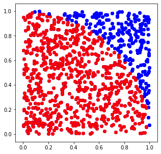

```python
plt.figure(figsize=(5,5))
i, s = 0, 0
while True:
    if i >= 1000:
        break
    else:
        i += 1
    x = np.random.random()
    y = np.random.random()
    plt.scatter(x, y, color='b')
    if (math.sqrt(x**2+y**2) < 1):
        plt.scatter(x, y, color='r')
        s += 1
    else:
        plt.scatter(x, y, color='b')
else:
    plt.show()
```

```python
print(s/1000*4)
```

```
3.032
```

#### Цикл for

```python
for i in range(10):
    print(i**2, end=" ")
```

```
0 1 4 9 16 25 36 49 64 81
```

#### Обработка исключений (конструкция try-except)

```python
try:
    print(1/0)
except:
    print("problem")
```

```
problem
```

```python
a = list(range(0,11))[::-1]
print(a)
```

```
[10, 9, 8, 7, 6, 5, 4, 3, 2, 1, 0]
```

```python
for d in a:
    try:
        print(round(10/d,2), end=" ")
    except ZeroDivisionError:
        print("Zero Division error")
```

```
1.0 1.11 1.25 1.43 1.67 2.0 2.5 3.33 5.0 10.0 Zero Division error
```

```python
class MyException(Exception):
    pass
```

#### Проверка выполнения условия (оператор assert)

```python
for i in range(10):
    print(i)
    try:
        assert(i!=5)
    except:
        print("Проблема")
```

```
0
1
2
3
4
5
Проблема
6
7
8
9
```

Назад к Оглавлению

## Ввод и вывод данных

#### Работа с консолью

```python
print("{:.4f}".format(1.111))
```

```
1.1110
```

```python
a = "\'text\'"
print(a)
print("--{}--".format(a))
print("--{!r}--".format(a))
```

```
'text'
--'text'--
--"'text'"--
```

#### Метод join

```python
a = [[i+j for i in range(5)] for j in range(6)]
for row in a:
    print(" ".join([str(element) for element in row]))
```

```
0 1 2 3 4
1 2 3 4 5
2 3 4 5 6
3 4 5 6 7
4 5 6 7 8
5 6 7 8 9
```

#### Вывод на экран свойств объекта

```python
class person():
    name = ""
    age = 0
    def __init__(self, n, a):
        self.name = n
        self.age = a
    def str():
        print("class person")

me = person("Yury", 42)
he = person("Ivan", 41)
print("my name: {0.name}, his age: {1.age}".format(me, he))
```

```
my name: Yury, his age: 41
```

#### Запись в файл

```python
with open('a.out', 'w') as f:
    f.write("hello")
f.close()
```

#### Чтение из файла

```python
with open('a.out', 'r') as f:
    print(f.read())
f.close()
```

```
hello
```

#### Сериализация данных с использованием pickle

```python
import pickle
```

```python
s = {"name": "Ivan", "surname": "Ivanov", "age": 20}
```

```python
b = pickle.dumps(s)
print(type(b), b)
s1 = pickle.loads(b)
print(s1)
```

```
<class 'bytes'> b'\x80\x03}q\x00(X\x04\x00\x00\x00nameq\x01X\x04\x00\x00\x00Ivanq\x02X\x07\x00\x00\x00surnameq\x03X\x06\x00\x00\x00Ivanovq\x04X\x03\x00\x00\x00ageq\x05K\x14u.'
{'name': 'Ivan', 'surname': 'Ivanov', 'age': 20}
```

#### Ограничение вывода сообщений на экран

```python
import warnings
warnings.filterwarnings('ignore')
```

Назад к Оглавлению

# Работа с сетью

```python
import socket
```

Назад к Оглавлению

# Специализированные библиотеки

## Специальные структурированные типы данных (модуль collections)

#### Словарь Counter для подсчета частотности элементов

Загрузка.

```python
from collections import Counter
```

Подсчет частот элементов

```python
a = [1, 2, 1, 3, 1, 3]
c = Counter(a)
print(c)
print(c.keys())
print(c.values())
print(c.items())
```

```
Counter({1: 3, 3: 2, 2: 1})
dict_keys([1, 2, 3])
dict_values([3, 1, 2])
dict_items([(1, 3), (2, 1), (3, 2)])
```

Использование для подсчета частоты слов

```python
import urllib
# скачаем содержимое html страницы www.usurt.ru
page = urllib.request.urlopen("http://www.usurt.ru")
info = page.read().decode("utf-8")
```

```python
# разделим на отдельные слова, отделяемые пробелами
tokens = info.replace('\n', ' ')
tokens = tokens.replace('\r', ' ')
tokens = tokens.split(' ')

print("Всего {} токенов, разделяемых пробелами".format(len(tokens)))

cleaned_tokens = []

# оставим только слова
for token in tokens:
    if token.isalpha():
        cleaned_tokens.append(token)

print("Среди инх {} токенов, являющихся словами".format(len(cleaned_tokens)))
print("Среди них {} уникальных".format(len(set(cleaned_tokens))))
```

```
Всего 80197 токенов, разделяемых пробелами
Среди инх 619 токенов, являющихся словами
Среди них 357 уникальных
```

```python
tokens_counter = Counter()
for token in cleaned_tokens:
    tokens_counter[token]+=1
```

```python
l = list(tokens_counter.keys())
for i in l:
    print(i, end=" ")
```

```
lte IE lt Головной вуз УрГУПС Modal location Екатеринбург железнодорожного транспорта колледж Челябинск институт путей сообщения Курган Пермь Тюмень в городе Нижний Нижнем Златоуст cached и гостиничное хозяйство железных на планирование организация glyphicon сайта для container cache read ВО Уральск…
```

```python
print(list(tokens_counter.elements())[10:20])
```

```
['УрГУПС', 'УрГУПС', 'УрГУПС', 'УрГУПС', 'УрГУПС', 'УрГУПС', 'УрГУПС', 'УрГУПС', 'Modal', 'Modal']
```

```python
print(tokens_counter.values())
```

```
dict_values([2, 4, 1, 1, 2, 8, 2, 2, 1, 9, 5, 1, 1, 4, 4, 2, 1, 1, 1, 29, 3, 1, 1, 1, 8, 39, 3, 3, 3, 13, 3, 3, 2, 1, 6, 1, 1, 1, 1, 2, 2, 2, 1, 1, 1, 1, 1, 2, 3, 2, 1, 1, 6, 3, 4, 3, 3, 3, 3, 3, 3, 3, 2, 1, 2, 3, 8, 1, 1, 1, 1, 1, 1, 1, 1, 1, 1, 1, 1, 2, 1, 1, 2, 1, 1, 12, 1, 1, 1, 1, 1, 2, 2, 1, 1…
```

```python
print(tokens_counter.most_common(10))
```

```
[('и', 39), ('в', 29), ('на', 13), ('о', 12), ('железнодорожного', 9), ('УрГУПС', 8), ('cached', 8), ('clearfix', 8), ('с', 8), ('для', 6)]
```

Операции над объектами Counter

```python
c1 = Counter([1,2,1,2,3])
print(c1)
c1 = c1 + Counter([1,2,3,4,4])
print(c1)
c1 = c1 - Counter([4])
print(c1)
c1 += Counter() # удалаем все элементы, встречающиеся меньше одного раза
print(c1)
```

```
Counter({1: 2, 2: 2, 3: 1})
Counter({1: 3, 2: 3, 3: 2, 4: 2})
Counter({1: 3, 2: 3, 3: 2, 4: 1})
Counter({1: 3, 2: 3, 3: 2, 4: 1})
```

#### defaultdict()

Упрощает работу со словарем - если ключ отсутствует, то автоматически создает его.

```python
from collections import defaultdict

dd_int = defaultdict(int)
dd_int[1] = 1
dd_int[1] += 1
print(dd_int)

dd_list = defaultdict(list)
dd_list[5].append(1)
dd_list[5].append(2)
print(dd_list)
```

```
defaultdict(<class 'int'>, {1: 2})
defaultdict(<class 'list'>, {5: [1, 2]})
```

#### deque

Динамический массив, позволяет добавлять и читать элементы с начала и с конца.

```python
from collections import deque
```

```python
d = deque(maxlen=7)
for i in range(10):
    d.append(i)
    print(d)
```

```
deque([0], maxlen=7)
deque([0, 1], maxlen=7)
deque([0, 1, 2], maxlen=7)
deque([0, 1, 2, 3], maxlen=7)
deque([0, 1, 2, 3, 4], maxlen=7)
deque([0, 1, 2, 3, 4, 5], maxlen=7)
deque([0, 1, 2, 3, 4, 5, 6], maxlen=7)
deque([1, 2, 3, 4, 5, 6, 7], maxlen=7)
deque([2, 3, 4, 5, 6, 7, 8], maxlen=7)
deque([3, 4, 5, 6, 7, 8, 9], maxlen=7)
```

```python
d.appendleft(11)
print(d)
```

```
deque([11, 3, 4, 5, 6, 7, 8], maxlen=7)
```

```python
v1 = d.pop()
print(v1, d)
v2 = d.popleft()
print(v2, d)
```

```
8 deque([11, 3, 4, 5, 6, 7], maxlen=7)
11 deque([3, 4, 5, 6, 7], maxlen=7)
```

#### OrderedDict

Позволяет упорядочивать элементы словаря.

```python
from collections import OrderedDict
import json
```

```python
d1 = {'name': 'Ivan', 'age': 30, 'surname': 'Ivanov'}
print(d1)
```

```
{'name': 'Ivan', 'age': 30, 'surname': 'Ivanov'}
```

```python
d2 = OrderedDict()
d2['age']  = 30
d2['name'] = 'Ivan'
d2['surname'] = 'Ivanov'
print(d2)
```

```
OrderedDict([('age', 30), ('name', 'Ivan'), ('surname', 'Ivanov')])
```

```python
json.dumps(d2)
```

```
'{"age": 30, "name": "Ivan", "surname": "Ivanov"}'
```

Назад к Оглавлению

# Работа с системным окружением

#### Загрузка библиотеки

```python
import os
```

#### Проверка существования файла

```python
os.path.exists('a1.out')
```

```
True
```

#### Напечатать названия всех файлов в заданной директории

```python
#for dirname, _, filenames in os.walk('.'):
#    for filename in filenames:
#        print(os.path.join(dirname, filename))
```

#### Получить значение переменной окружения

```python
print(os.environ.get('PATH'))
```

```
C:\Users\Chernishov\AppData\Local\Continuum\anaconda3;C:\Users\Chernishov\AppData\Local\Continuum\anaconda3\Library\mingw-w64\bin;C:\Users\Chernishov\AppData\Local\Continuum\anaconda3\Library\usr\bin;C:\Users\Chernishov\AppData\Local\Continuum\anaconda3\Library\bin;C:\Users\Chernishov\AppData\Local\…
```

#### Получить информацию о количестве используемых процессоров

```python
import multiprocessing
```

```python
print(multiprocessing.cpu_count())
```

```
4
```

```python
print(multiprocessing.current_process())
```

```
<_MainProcess(MainProcess, started)>
```

Назад к Оглавлению

# Работа со временем (модуль time)

#### Загрузка библиотеки

```python
import time
```

```python
print(time.time()) # время в секундах с 01.01.1970 (unix-time)
```

```
1592997104.590551
```

#### Демонстрация скорости работы векторизованных данных по сравнению с обычным циклом

```python
a = np.random.rand(1000000)
b = np.random.rand(1000000)

tic = time.time()
c = np.dot(a, b)
toc = time.time()
print("np.dot works {} ms".format(1000*(toc-tic)))

c = 0
tic = time.time()
for i in range(1000000):
    c += a[i]*b[i]
toc = time.time()
print("for loop works {} ms".format(1000*(toc-tic)))
```

```
np.dot works 3.000020980834961 ms
for loop works 721.041202545166 ms
```

Назад к Оглавлению

# Регулярные выражения

```python
import re
```

#### Проверка, что выражение начинается с заданного символа

```python
bool(re.match("a", "cat")), bool(re.match("c", "cat"))
```

```
(False, True)
```

#### Проверка наличия символа в строке

```python
bool(re.search("с", "слово")), bool(re.search("ф", "слово"))
```

```
(True, False)
```

#### Разбиение

```python
re.split("[а]", "абракадабра")
```

```
['', 'бр', 'к', 'д', 'бр', '']
```

```python
предложение = "Это простое предложение, содержащее пробелы."
re.split("[ .,]", предложение)
```

```
['Это', 'простое', 'предложение', '', 'содержащее', 'пробелы', '']
```

#### Подстановка

```python
re.sub("a", "b", "ababab")
```

```
'bbbbbb'
```

Назад к Оглавлению

# Магические команды

Команды, привязанные к строке, начинаются с %. Команды, привязанные к ячейке, начинаются с %%.

#### Список всех магических команд

```python
%lsmagic
```

```
Available line magics:
%alias  %alias_magic  %autoawait  %autocall  %automagic  %autosave  %bookmark  %cd  %clear  %cls  %colors  %conda  %config  %connect_info  %copy  %ddir  %debug  %dhist  %dirs  %doctest_mode  %echo  %ed  %edit  %env  %gui  %hist  %history  %killbgscripts  %ldir  %less  %load  %load_ext  %loadpy  %log…

Available cell magics:
%%!  %%HTML  %%SVG  %%bash  %%capture  %%cmd  %%debug  %%file  %%html  %%javascript  %%js  %%latex  %%markdown  %%perl  %%prun  %%pypy  %%python  %%python2  %%python3  %%ruby  %%script  %%sh  %%svg  %%sx  %%system  %%time  %%timeit  %%writefile

Automagic is ON, % prefix IS NOT needed for line magics.
```

#### Выполнение скрипта из внешнего файла

```python
with open('script.py', 'w') as f:
    f.write("print('Hello')")
f.close()
%run script.py
```

```
Hello
```

#### Оценка времени выполнения строки кода

```python
%time sum([i**5 for i in range(100000)])
```

```
Wall time: 63 ms
```

```
166661666708333333332500000000
```

```python
%timeit 7 in [i**5 for i in range(100000)]
```

```
57.5 ms ± 2.07 ms per loop (mean ± std. dev. of 7 runs, 10 loops each)
```

```python
a = np.array([i**5 for i in range(100000)])
%timeit 7 in a
```

```
2.33 ms ± 83.2 µs per loop (mean ± std. dev. of 7 runs, 100 loops each)
```

#### Оценка времени выполнения кода в ячейке

```python
%%time
s = 0
a = [i for i in range(1000000)]
b = [i for i in range(1000000)]
for i in range(len(a)):
    s += a[i]*b[i]
print(s)
```

```
333332833333500000
Wall time: 582 ms
```

#### Запись в файл

```python
%%writefile script.py

def f(a):
    print(a**2)
f(2)
```

```
Overwriting script.py
```

```python
%run script.py
```

```
4
```

#### Просмотр содержимого файла

```python
%pycat script.py
```

#### Получение информации обо всех используемых глобальных переменных

```python
%who
```

```
A	 B	 C	 Counter	 D	 MyException	 MySet	 OrderedDict	 SLICE
a	 acos	 acosh	 age	 asin	 asinh	 atan	 atan2	 atanh
b	 c	 c1	 ceil	 cleaned_tokens	 copysign	 cos	 cosh	 d
d1	 d2	 dd_int	 dd_list	 defaultdict	 degrees	 deque	 e	 elem
erf	 erfc	 exp	 expm1	 f	 f1	 f2	 fDecorator	 fSquare
fSum	 fSum1	 f_hardworking_slave	 f_lazy_slave	 f_master	 fabs	 factorial	 floor	 fmod
frexp	 fs	 fsum	 g	 g1	 g2	 gamma	 gcd	 gen1
gen2	 gen3	 gen4	 gen5	 gen6	 gen7	 he	 hello	 hypot
i	 ifEven	 inf	 info	 inspect	 isclose	 isfinite	 isinf	 isnan
j	 json	 l	 ldexp	 lgamma	 log	 log10	 log1p	 log2
m	 main	 makebold	 makeitalic	 math	 me	 modf	 multiprocessing	 myDecorator
nan	 np	 os	 page	 partial	 person	 pi	 pickle	 plt
pow	 r	 radians	 re	 reduce	 remainder	 row	 s	 s1
s2	 s3	 s4	 s5	 s6	 sin	 sinh	 socket	 sqrt
tan	 tanh	 task	 tasks	 tau	 text	 tic	 time	 toc
token	 tokens	 tokens_counter	 trunc	 urllib	 v	 v1	 v2	 warnings
x	 y	 предложение
```

```python
%who str
```

```
info	 text	 token	 предложение
```

```python
%who int
```

```
age	 elem	 i	 j	 r	 s	 v	 v1	 v2
```

```python
%who float
```

```
e	 inf	 nan	 pi	 s2	 tau	 tic	 toc	 x
y
```

```python
%who list
```

```
a	 b	 cleaned_tokens	 l	 m	 row	 tasks	 tokens
```

```python
%who dict
```

```
d1	 s1
```

```python
%who function
```

```
f	 f1	 f2	 fDecorator	 fSquare	 fSum	 f_hardworking_slave	 f_lazy_slave	 f_master
gen1	 gen2	 gen3	 gen4	 gen5	 gen6	 gen7	 hello	 ifEven
main	 makebold	 makeitalic	 myDecorator
```

#### Использование html кода в блокноте

```python
%%html

<h1>Таблица с информацией</h1>
<table>
<tr>
    <td>A</td> <td>B</td>
</tr>
<tr>
    <td>C</td> <td>D</td>
</tr>
</table>
```

Таблица с информацией

| A | B |
| --- | --- |
| C | D |

#### Работа с matplotlib в блокноте

Доступные backend

```python
%matplotlib --list
```

```
Available matplotlib backends: ['tk', 'gtk', 'gtk3', 'wx', 'qt4', 'qt5', 'qt', 'osx', 'nbagg', 'notebook', 'agg', 'svg', 'pdf', 'ps', 'inline', 'ipympl', 'widget']
```

```python
import matplotlib.pyplot as plt
%matplotlib inline
```

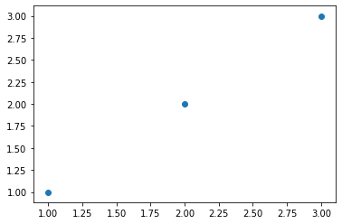

```python
plt.scatter([1,2,3], [1,2,3])
```

#### Переменные среды

```python
%env PATH
```

```
'C:\\Users\\Chernishov\\AppData\\Local\\Continuum\\anaconda3;C:\\Users\\Chernishov\\AppData\\Local\\Continuum\\anaconda3\\Library\\mingw-w64\\bin;C:\\Users\\Chernishov\\AppData\\Local\\Continuum\\anaconda3\\Library\\usr\\bin;C:\\Users\\Chernishov\\AppData\\Local\\Continuum\\anaconda3\\Library\\bin;C…
```

#### Получение подробной информации об объекте

```python
a = [1, 2, 3]
%pinfo a
```

Назад к Оглавлению

# Трюки Python

#### Распаковка итерируемого объекта переменной длины

```python
s = ['Ivan', 'Ivanov', 'Ivanov@mail.com', '+7111111111', '+7211111111']
```

```python
name, surname, email, *phones = s
```

```python
print(name)
```

```
Ivan
```

```python
print(phones)
```

```
['+7111111111', '+7211111111']
```

#### Вывести n наибольших и наименьших элементов списка

```python
import heapq
```

```python
a = [np.random.randint(-10,10) for _ in range(10)]
print(a)
```

```
[0, 8, 0, 0, 4, -10, 1, -5, 5, 6]
```

```python
print(heapq.nlargest(3,a))
print(heapq.nsmallest(3,a))
print(heapq.nlargest(3,a,key=lambda x:x**2))
```

```
[8, 6, 5]
[-10, -5, 0]
[-10, 8, 6]
```

```python
heapq.heapify(a)
print(a)
```

```
[-10, -5, 0, 0, 4, 0, 1, 8, 5, 6]
```

```python
d = heapq.heappop(a)
print(d)
print(a)
```

```
-10
[-5, 0, 0, 5, 4, 0, 1, 8, 6]
```

#### Создать класс, упорядочивающий элементы (объекты) по приоритету (поле объекта)

```python
class PriorityQueue:
    def __init__(self):
        self._queue = []
        self._index = 0
    def fAddItem(self,item,priority):
        heapq.heappush(self._queue,(-priority, self._index, item))
        self._index += 1
    def fGetItem(self):
        return heapq.heappop(self._queue)
```

```python
class Item:
    def __init__(self, name):
        self.name = name
    def __repr__(self):
        return "Item: name {!r}".format(self.name)
```

```python
q = PriorityQueue()
q.fAddItem(Item("Ivan"),1)
q.fAddItem(Item("Petr"),20)
q.fAddItem(Item("Yury"),3)
```

```python
print(q.fGetItem())
print(q.fGetItem())
```

```
(-20, 1, Item: name 'Petr')
(-3, 2, Item: name 'Yury')
```

#### Создать словарь, в котором по одному ключу находятся несколько элкментов.

```python
d = defaultdict(list)
d['a'].append(1)
print(d)
d['b'].append(2)
print(d)
d['b'].append(3)
print(d)
```

```
defaultdict(<class 'list'>, {'a': [1]})
defaultdict(<class 'list'>, {'a': [1], 'b': [2]})
defaultdict(<class 'list'>, {'a': [1], 'b': [2, 3]})
```

#### В словаре найти пару "ключ"-"значение" с наименьшим значением

```python
s = {
    "a": 1,
    "b": 12,
    "c": -1
}
print(s)
```

```
{'a': 1, 'b': 12, 'c': -1}
```

```python
print(min(s,key=lambda k: s[k]))
print(s[min(s,key=lambda k: s[k])])
```

```
c
-1
```

```python
for elem in zip(s.values(),s.keys()):
    print(elem)
print('-'*4)
print(min(zip(s.values(),s.keys())))
print(max(zip(s.values(),s.keys())))
```

```
(1, 'a')
(12, 'b')
(-1, 'c')
----
(-1, 'c')
(12, 'b')
```

#### У двух словарей найти общие ключи и значения

```python
s1 = {"a": 1, "b": 12, "c": -1}
s2 = {"a": 1, "d": 3,  "e": -1}
```

```python
print(s1.keys() & s2.keys())
print(s1.keys() - s2.keys())
print(s2.keys() - s1.keys())
print(s1.items() & s2.items())
```

```
{'a'}
{'b', 'c'}
{'e', 'd'}
{('a', 1)}
```

#### Создать новый словарь на основе старого из которого удалить элементы с определенными ключами

```python
print(s1)
```

```
{'a': 1, 'b': 12, 'c': -1}
```

```python
s3 = {k: s1[k] for k in s1.keys() - {'a','b'}}
print(s3)
```

```
{'c': -1}
```

#### Удалить повторяющиеся элементы из хэшируемого и нехэшируемого типа

```python
def fDelDuplicate(items, key=None):
    seen = set()
    for item in items:
        val = item if key is None else key(item)
        if val not in seen:
            yield item
            seen.add(val)
```

```python
a = [1,2,-3,1,2,-1]
print(set(a))
print(list(fDelDuplicate(a)))
```

```
{1, 2, -3, -1}
[1, 2, -3, -1]
```

```python
s = [{'name':'Ivan', 'age': 20}, {'name':'Ivan', 'age': 20}, {'name':'Ivan', 'age': 30},{'name':'Petr', 'age': 30}]
print(s)
print(list(fDelDuplicate(s,key=lambda t: (t['name'], t['age']))))
print(list(fDelDuplicate(s,key=lambda t: t['name'])))
print(list(fDelDuplicate(s,key=lambda t: t['age'])))
```

```
[{'name': 'Ivan', 'age': 20}, {'name': 'Ivan', 'age': 20}, {'name': 'Ivan', 'age': 30}, {'name': 'Petr', 'age': 30}]
[{'name': 'Ivan', 'age': 20}, {'name': 'Ivan', 'age': 30}, {'name': 'Petr', 'age': 30}]
[{'name': 'Ivan', 'age': 20}, {'name': 'Petr', 'age': 30}]
[{'name': 'Ivan', 'age': 20}, {'name': 'Ivan', 'age': 30}]
```

#### Создать древовидную структуру и пройти по ее узлам поиском в глубину

```python
class Node():
    def __init__(self, value):
        self._value = value
        self._children = []
    def __repr__(self):
        return "Node {!r}".format(self._value)
    def add_child(self, child_node):
        self._children.append(child_node)
    def __iter__(self):
        return iter(self._children)
    def depth(self):
        yield self
        for c in self:
            yield from c.depth()
```

```python
root = Node(0)
child1 = Node(1)
child11 = Node(11)
child2 = Node(2)
root.add_child(child1)
child1.add_child(child11)
root.add_child(child2)
for c in root.depth():
    print(c)
```

```
Node 0
Node 1
Node 11
Node 2
```

#### Сделать срез для генератора

```python
def gSquare(n):
    for i in range(n):
        yield i**2
```

```python
a = gSquare(100)
for elem in a:
    print(elem, end=" ")
```

```
0 1 4 9 16 25 36 49 64 81 100 121 144 169 196 225 256 289 324 361 400 441 484 529 576 625 676 729 784 841 900 961 1024 1089 1156 1225 1296 1369 1444 1521 1600 1681 1764 1849 1936 2025 2116 2209 2304 2401 2500 2601 2704 2809 2916 3025 3136 3249 3364 3481 3600 3721 3844 3969 4096 4225 4356 4489 4624 4…
```

```python
import itertools
```

```python
a = gSquare(100)
for elem in itertools.islice(a,90,100):
    print(elem, end=" ")
```

```
8100 8281 8464 8649 8836 9025 9216 9409 9604 9801
```

Назад к Оглавлению

# Полезные ссылки

- python.org
- colab.research.google.com

Назад к Оглавлению